# Classify & Sample Meadows for Sourcewater Study

Updated 2016-09-20

## Objectives

- *Determine sourcewater relationship with HGM type and NDVI-NDWI*
- *Create/frame metrics that are quantifiable and stand alone*
- *Tie this to prioritization for restoration*
- **Vulnerable vs. Resilient**:
  - **VULNERABLE**: Incision, land use, climate
  - **RESILIENT**: Sourcewater, more groundwater driven is more resilient, more surfacewater is less resilient

## Steps

1. Pick 20-25 Meadows
2. Conduct on the ground/remote HGM typing to get overall HGM proportions for meadows
3. WQ sampling: minimum of 2 WQ sample times per meadow, (early summer/fall)
4. Multilevel-bayesian mixed modeling

### Classification/Selection

Classify 120 by these factors and randomly pick from these, minimum of X for each type?

- *HGM Type* (pick 3 mdws of each HGM type, 7 types, exclude *DRY*)
- *Elevation Class* (>2000-2100: Snowline, or treeline, and <=2000)

Randomly select from these 14 bins, if holes talk with Dave and add meadows. NFWF meadows to this? Van Norden as well. Might need fewer meadows from Dave’s set if we can fill bins with NFWF/Van Norden

- Latitude (Modoc/Lassen, Plumas/Tahoe/ED, Southern Central Sierra (Stan/Seq/Sierra/Inyo))

### HGM Types

|  | hgm_type | hgm_code | hgm_class |
| --- | --- | --- | --- |
| 1 | lacustrine fringe | lf | 1 |
| 2 | depressional | dep | 2 |
| 3 | discharge-slope-hillslope | ds | 3 |
| 4 | riparian-discharge-slope | rip-ds | 4 |
| 5 | riparian | rip | 5 |
| 6 | subsurface-discharge-slope | sub-ds | 6 |
| 7 | subsurface | sub | 7 |
| 8 | dry | dry | 8 |

### Classifying & Binning Meadows

So first, a quick overview of the data. Across the **8** **HGM Source Types**, several types only have 2 meadows (type 6 and 8). Furthermore, those all fall into the same elevation bin (nothing above 2000 m in class 7 and 8). See below. If we want to select 3 per type, we’d need more meadows just to meet the minimum, and that would require selecting all available regardless.

|  | hgm_class | n() | mean(ELEV_MEAN) | max(ELEV_MEAN) |
| --- | --- | --- | --- | --- |
| 1 | 1 | 4 | 2072.3325 | 2682.74 |
| 2 | 2 | 8 | 1944.5825 | 3136.71 |
| 3 | 3 | 14 | 1764.78571428571 | 2633.97 |
| 4 | 4 | 32 | 2343.44115625 | 3059.42 |
| 5 | 5 | 47 | 2115.46063829787 | 3055.97 |
| 6 | 6 | 2 | 2582.835 | 2659.28 |
| 7 | 7 | 5 | 1719.426 | 1921.14 |
| 8 | 8 | 2 | 1698.94 | 1698.94 |

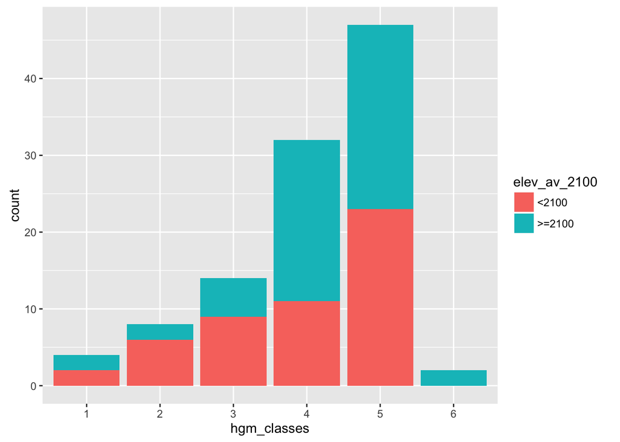

Assuming we select 2 meadows per bin to start, the easiest approach to randomly sample (from an already small sample), is to use the *`sample`* function in R, after grouping by *hgm class* & *elevation*.

|  | PLOT | METHOD | PLOTNAME2 | UCDavisObject_ID | elev | ELEV_MEAN | hgm_class | AREA_ACRE | LAT_DD | LONG_DD | Shape_Area | hgm_classes | elev_av_2100 |
| --- | --- | --- | --- | --- | --- | --- | --- | --- | --- | --- | --- | --- | --- |
| 1 | LAS0119 | rooted frequency | LAS0119 -Bear Valle Res. | UCDSNM016562 | 1796 | 1796.03 | 1 | 119.2974811 | 40.77553261 | -121.1186317 | 482781.7087 | 1 | &lt;2100 |
| 2 | LAS0102 | rooted frequency | LAS0102 -Big Jacks | UCDSNM016577 | 1640 | 1640.25 | 1 | 48.66976537 | 40.79433567 | -120.9870818 | 196960.3404 | 1 | &lt;2100 |
| 3 | ELD0101 | rooted frequency | ELD0101 -ONION VALLEY | UCDSNM012349 | 2170 | 2170.31 | 1 | 1.615009202 | 38.56506168 | -120.1884221 | 6535.736505 | 1 | &gt;=2100 |
| 4 | STA0108 | rooted frequency | STA0108 -Upper Relief Valley | UCDSNM011455 | 2685 | 2682.74 | 1 | 78.00646282 | 38.22223903 | -119.778073 | 315682.2178 | 1 | &gt;=2100 |
| 5 | ELD0109 | rooted frequency | ELD0109 -Shaw Flat | UCDSNM012729 | 2044 | 2044.76 | 2 | 4.341858002 | 38.65343304 | -120.1904033 | 17570.94622 | 2 | &lt;2100 |
| 6 | LAS0103 | rooted frequency | LAS0103 -Upper Long Valley | UCDSNM016565 | 1634 | 1634.95 | 2 | 14.27490935 | 40.78813601 | -121.046434 | 57768.73967 | 2 | &lt;2100 |
| 7 | INY0105 | rooted frequency | INY0105 -UPPER BAKER | UCDSNM005339 | 1607 | 3136.71 | 2 | 61.00831109 | 37.16536685 | -118.4780208 | 246892.8631 | 2 | &gt;=2100 |
| 8 | TAH0123 | rooted frequency | TAH0123 -BARKER MEADOW WEST | UCDSNM014209 | 2193 | 2222.11 | 2 | 7.353242794 | 39.05906016 | -120.2491904 | 29757.63686 | 2 | &gt;=2100 |
| 9 | ELD0104 | rooted frequency | ELD0104 -BARNEY MEADOW | UCDSNM012306 | 1224 | 1224.98 | 3 | 3.704709529 | 38.55064034 | -120.4626866 | 14992.48752 | 3 | &lt;2100 |
| 10 | STA0112 | rooted frequency | STA0112 -Lower Milk Ranch Spring | UCDSNM010404 | 1584 | 1587.78 | 3 | 1.765672552 | 38.0453133 | -120.0674347 | 7145.451888 | 3 | &lt;2100 |

[output cut: 14 more lines]

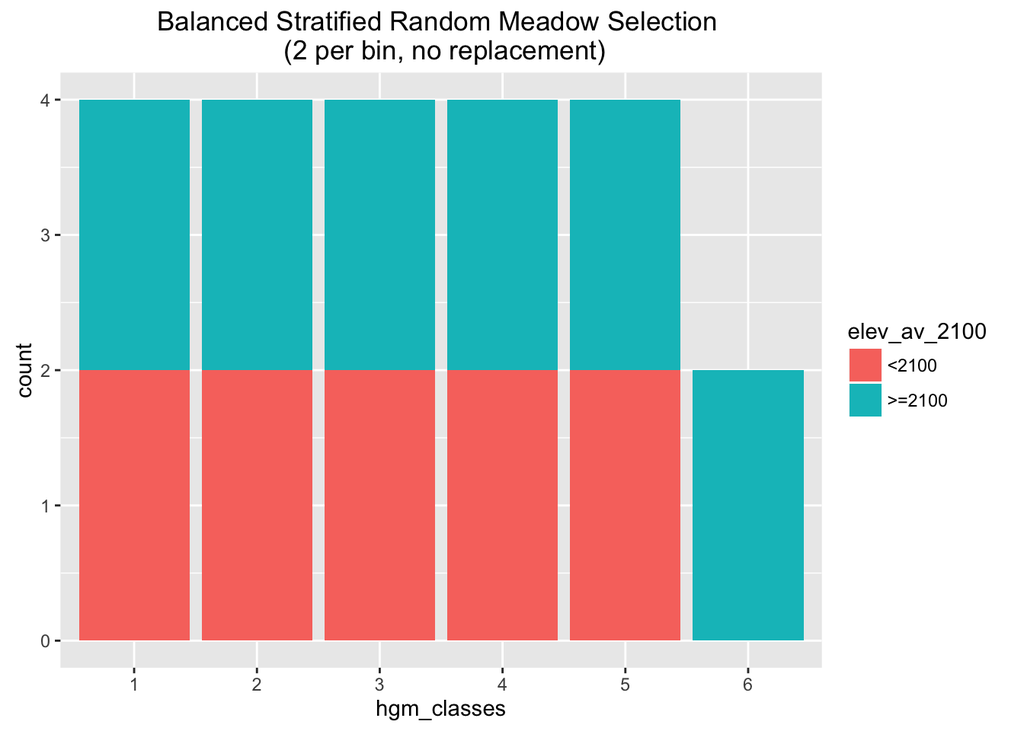

Haven’t dealt with selecting across latitude yet, but I’ll get a map into this sometime soon.